# Natural Language Processing

```r
library(dplyr)
library(ggplot2)
library(readr)
library(stringi)
library(tidyr)
library(magrittr)

theme_set(theme_minimal())
```

This RMarkdown script is a revised and condensed version of ninth chapter from the book “Humanities Data in R”. There have been many changes over the past 5 year in regards to NLP technology and this revision uses our new R package (cleanNLP) in place of the older and unsupported coreNLP. The book itself is still useful as it contains additional information about each of the NLP tasks. We suggest pairing the exposition in the book but to run the R code from this file instead.

# Tokenization & Sentence Splitting

Consider (an English translation of) the opening lines to Albert Camus’s *l’Étranger*. Let’s represent this as a length one character vector in R.

```r
camus <- "Mother died today. Or, maybe, yesterday; I can't be sure."
```

A practical, and seemingly simple, first step in processing this string is to split it into a longer character vector where each element contains a single word. But what exactly is meant by a word? Are punctuation marks separate words? What about contractions, hyphens, or compound nouns such as ‘New York City’? If we split this string apart using just the presence of spaces the result seems approximately reasonable, but less than perfect.

```r
stri_split(camus, fixed=" ")
```

```
## [[1]]
##  [1] "Mother"     "died"       "today."     "Or,"        "maybe,"
##  [6] "yesterday;" "I"          "can't"      "be"         "sure."
```

The process of splitting text into meaningful elements is called tokenization. For an English text the difficult task is catching the myriad of rules and exceptions. Rather than re-creating and re-implementing these conditions, it is better to use a well-tested library to tokenize our string.

Throughout this chapter will be make use of an R package we have developed called **cleanNLP**. The package provides various backends that use different libraries to perform various NLP tasks, but then transforms their output into a common format. To start, we will use the backend because it is reasonably powerful but also easy to install (in fact, you should not need to do anything other than install cleanNLP from CRAN). To start, we load the package and call to the function to indicate that we want to use this particular backend.

```r
library(cleanNLP)
cnlp_init_udpipe()
```

The first time you run this function, R will automatically download the language model from the internet. This may take a minute or two depending on your internet connection; the file will be cached for future use.

In order to process a string of text using we pass a text through the function . We will explore the various parts of the output throughout this chapter.

```r
annotation <- cnlp_annotate(camus)
```

```
## Processed document 1 of 1
```

```r
names(annotation)
```

```
## [1] "token"    "document"
```

The two elements of the annotation give information about the detected tokens and the input documents, respectively. Most of the useful information is in the tokens table, such as an improved version of tokenization as seen here:

```r
token <- annotation$token
token$token
```

```
##  [1] "Mother"    "died"      "today"     "."         "Or"
##  [6] ","         "maybe"     ","         "yesterday" ";"
## [11] "I"         "ca"        "n't"       "be"        "sure"
## [16] "."
```

```r
token$sid
```

```
##  [1] 1 1 1 1 2 2 2 2 2 2 2 2 2 2 2 2
```

The algorithm has assigned the first four tokens to the first sentence, and the remainder to a second sentence.

Can we learn anything useful directly from the output of this process of tokenization? In our short $16$ lemma example probably not, but consider applying the algorithm to a longer sample of text. We will now try to use a longer text, here the first published Sherlock Holmes short story, “A Scandal in Bohemia”.

```r
text <- readLines("data/holmes/01_a_scandal_in_bohemia.txt")
anno <- cnlp_annotate(paste(text, collapse="\n"))
```

```
## Processed document 1 of 1
```

```r
token <- anno$token
dim(token)
```

```
## [1] 10587    11
```

The output object is of exactly the same structure as our short example. In this case 10587 tokens have been processed. We can use the tokenization and sentence splitting to determine the length of every sentence in the text.

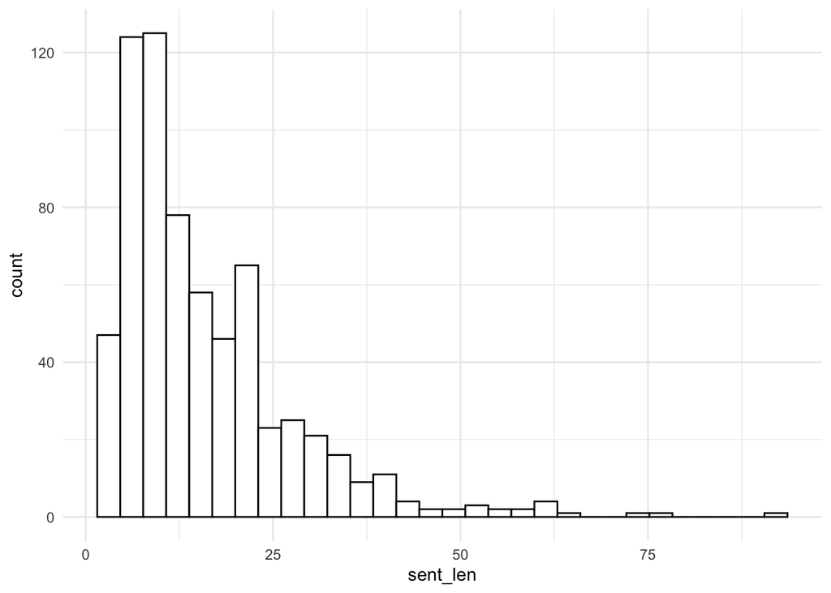

```r
token %>%
  group_by(doc_id, sid) %>%
  summarize(sent_len = length(tid)) %>%
  ggplot(aes(sent_len)) +
    geom_histogram(bins=30, color="black", fill="white")
```

The distribution shows a sharp peak of sentences less then 10 tokens long; this is fairly short, particularly when considering that punctuation is included in this count, and likely a product of the heavy use of dialogue in the text. A very small set of sentences are 60 or more tokens long. A close analysis of the original text reveals most of these to be part of a long deductive speech given by Sherlock Holmes towards the end of the story.

# Lemmatization & Part of Speech Tagging

While tokenizing simply splits the raw character input into groups, lemmatization goes further by converting each token into a representative lemma. For example, ‘go’ is the English lemma for words such as ‘gone’, ‘going’, and ‘went’. Nouns have their own process of lemmatization, such as converting all words into their singular form; for example ‘dogs’ becomes ‘dog’ and ‘mice’ becomes ‘mouse’.

Notice that lemmatization changes depending on the part of speech. Therefore, much like tokenization and sentence splitting, the task of tagging tokens with parts of speech and lemmatization is often accomplished in tandem. To demonstrate how both work in the package, we again turn to our annotation of ‘A Scandal in Bohemia’. Pulling out the second sentence (and obscuring some of the columns so as not to overwhelm ourselves with the rest of the output) reveals the following data frame.

```r
select(token, doc_id, sid, tid, token, lemma, xpos)
```

```
## # A tibble: 10,587 x 6
##    doc_id   sid tid   token    lemma    xpos
##     <int> <int> <chr> <chr>    <chr>    <chr>
##  1      1     1 1     To       to       IN
##  2      1     1 2     Sherlock Sherlock NNP
##  3      1     1 3     Holmes   Holme    NNP
##  4      1     1 4     she      she      PRP
##  5      1     1 5     is       be       VBZ
##  6      1     1 6     always   always   RB
##  7      1     1 7     the      the      DT
##  8      1     1 8     woman    woman    NN
##  9      1     1 9     .        .        .
## 10      1     2 1     I        I        PRP
## # … with 10,577 more rows
```

The part of speech codes come from the Penn Treebank Project, and contain many more categories compared to those typically taught in primary school grammar courses. For example **VBN** is the past participle form of a verb, whereas **VB** is the base form of a verb. A table from our annotation shows the entire set of possibilities.

```r
token %>%
  count(xpos, sort = TRUE)
```

```
## # A tibble: 43 x 2
##    xpos      n
##  * <chr> <int>
##  1 NN     1193
##  2 IN     1129
##  3 PRP     907
##  4 DT      829
##  5 .       671
##  6 ,       612
##  7 VBD     541
##  8 RB      540
##  9 JJ      473
## 10 VB      375
## # … with 33 more rows
```

We see that **JJS**, superlative adjectives, are relatively uncommon, and **NN** and **IN** tags, prepositions or subordinating conjunction, occur quite frequently. For a complete description of these tags see the technical report and justification from the Penn Treebank Project.

The extended set of parts of speech are quite useful, but many times a smaller set of more familiar options can better serve a particular purpose. Unviversal tagsets have been created as language-agnostic part of speech classifiers. A mapping from Penn Treebank codes into this smaller tag-set is provided as a column in the output. A table using universal tagsets reveals a smaller and more familiar list of parts of speech.

```r
token %>%
  count(upos, sort = TRUE)
```

```
## # A tibble: 17 x 2
##    upos      n
##  * <chr> <int>
##  1 PUNCT  1944
##  2 NOUN   1441
##  3 PRON   1396
##  4 VERB   1140
##  5 ADP     976
##  6 DET     819
##  7 AUX     636
##  8 ADV     569
##  9 ADJ     496
## 10 CCONJ   338
## 11 PROPN   277
## 12 PART    226
## 13 SCONJ   205
## 14 NUM      86
## 15 INTJ     36
## 16 SYM       1
## 17 X         1
```

We can see how these map to the more grainular part of speech codes as follows:

```r
token %>%
  count(upos, xpos) %>%
  filter(upos %in% c("NOUN", "PROPN", "VERB"))
```

```
## # A tibble: 10 x 3
##    upos  xpos      n
##    <chr> <chr> <int>
##  1 NOUN  NN     1174
##  2 NOUN  NNS     267
##  3 PROPN NNP     258
##  4 PROPN NNPS     19
##  5 VERB  VB      307
##  6 VERB  VBD     352
##  7 VERB  VBG     107
##  8 VERB  VBN     216
##  9 VERB  VBP      95
## 10 VERB  VBZ      63
```

With these universal part of speech codes, we can run some basic analysis on the sentences in our text. First, we count the number of nouns, pronouns, adjectives and verbs in each sentence using the function.

```r
pos_df <- token %>%
  group_by(doc_id, sid, upos) %>%
  summarize(n = n()) %>%
  pivot_wider(names_from="upos", values_from=n, values_fill = list(n=0))
pos_df
```

```
## # A tibble: 671 x 19
## # Groups:   doc_id, sid [671]
##    doc_id   sid   ADP   ADV   AUX   DET  NOUN  PRON PROPN PUNCT   ADJ  VERB
##     <int> <int> <int> <int> <int> <int> <int> <int> <int> <int> <int> <int>
##  1      1     1     1     1     1     1     1     1     2     1     0     0
##  2      1     2     1     1     1     1     1     3     0     1     1     2
##  3      1     3     2     0     0     1     2     3     0     1     1     2
##  4      1     4     1     0     0     1     2     2     2     1     0     3
##  5      1     5     1     2     1     1     2     1     0     4     3     1
##  6      1     6     2     1     3     4     5     5     0     4     2     5
##  7      1     7     3     1     0     3     4     1     0     2     0     1
##  8      1     8     2     0     1     2     6     1     0     2     2     1
##  9      1     9     3     1     1     4     7     3     0     1     4     6
## 10      1    10     6     1     2     4     6     2     0     4     6     1
## # … with 661 more rows, and 7 more variables: CCONJ <int>, PART <int>,
## #   SCONJ <int>, NUM <int>, INTJ <int>, SYM <int>, X <int>
```

An interesting stylistic question would be to see the within-sentence distribution of nouns (including pronouns), verbs, and adjectives. Due to the discrete nature of count data, a simple scatter plot will not work well. Instead we take advantage of over-plotting and color opacity to produce an interpretable visual description of this distribution.

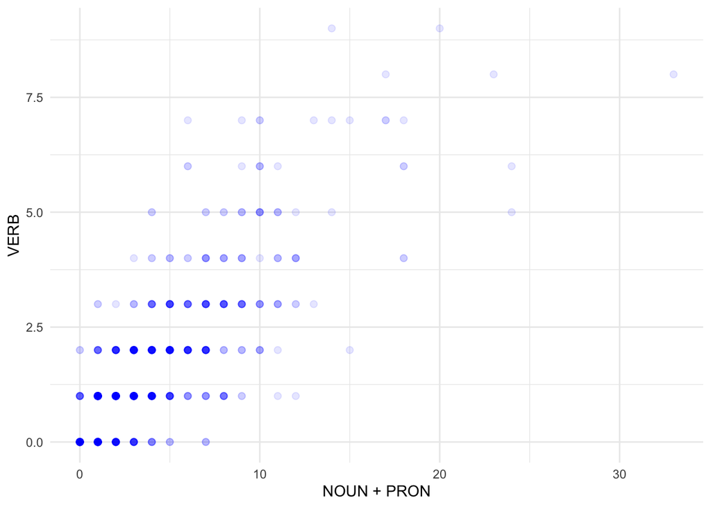

```r
pos_df %>%
  ggplot(aes(NOUN + PRON, VERB)) +
    geom_point(size=2, alpha=0.1, color="blue")
```

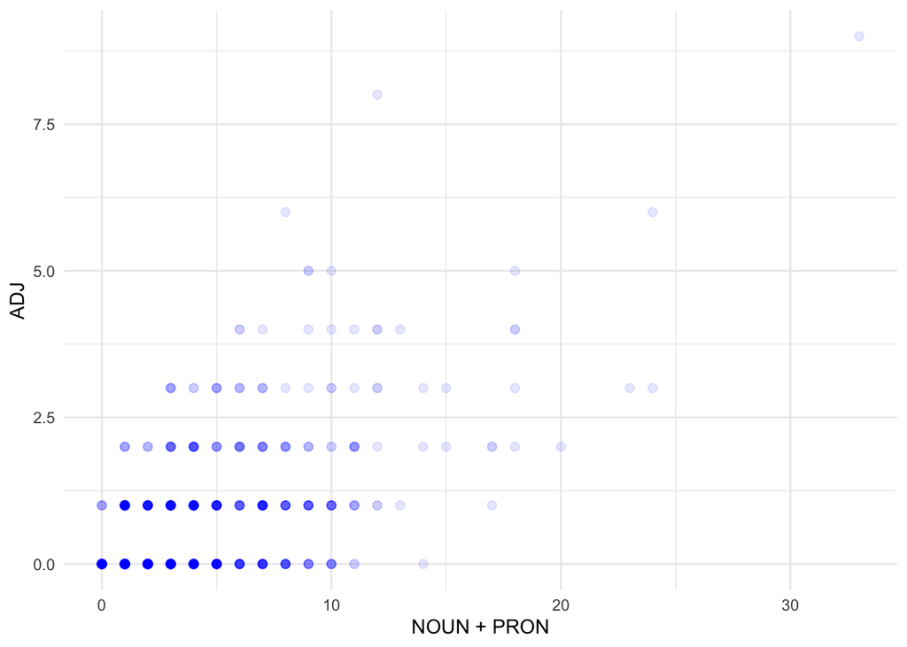

```r
pos_df %>%
  ggplot(aes(NOUN + PRON, ADJ)) +
    geom_point(size=2, alpha=0.1, color="blue")
```

Part of speech tagging also has the benefit of isolating function words, those with primarily grammatical usage such as prepositions and conjunctions, from those words with lexical meaning. Along with the use of lemmatization to collapse various word forms together, we can now gain potentially important contextual information from a text by identifying the most frequently used lemmas from a particular part of speech. The top $25$ noun lemmas from our sample text for example identify some of the key characters and objects of interest in the story.

```r
token %>%
  filter(upos %in% c("NOUN", "PROPN")) %>%
  count(lemma) %>%
  arrange(desc(n))
```

```
## # A tibble: 805 x 2
##    lemma          n
##    <chr>      <int>
##  1 Holmes        44
##  2 man           31
##  3 photograph    21
##  4 room          20
##  5 Majesty       18
##  6 hand          17
##  7 woman         17
##  8 house         16
##  9 matter        15
## 10 irene         14
## # … with 795 more rows
```

The third most common word, ‘photograph’, comes from the main objective presented in the story: the recovery of a scandalous photograph. References to the main characters are also present: ‘Sherlock Holmes’ of course, ‘Majesty’ being the royal client wishing to recover the photograph, and ‘Irene Adler’ the subject of the photograph in question.

Knowing beforehand the text in question, we were able to extract the character names from a table of the most common nouns. Identifying facts we already know however is not particularly useful. We can get a bit closer by looking only at proper nouns:

```r
token %>%
  filter(upos %in% c("PROPN")) %>%
  count(lemma) %>%
  arrange(desc(n))
```

```
## # A tibble: 115 x 2
##    lemma        n
##    <chr>    <int>
##  1 Holmes      28
##  2 irene       14
##  3 Adler       13
##  4 Briony      11
##  5 Lodge       11
##  6 King         9
##  7 Sherlock     9
##  8 Mr.          8
##  9 Bohemia      7
## 10 Norton       7
## # … with 105 more rows
```

The reduced list includes an increased set of characters, while removing many of the non-name nouns from the list. The results are still lacking as the titles and first and last names are not linked together. Some non-names are also present, such as the proper place names ‘Europe’ and ‘London’. In order to resolve these issues we need to discern relationships between pairs of words, rather than working with lemmas individually.

# Dependencies

To this point, we have primarily worked with individual words, tokens, and lemmas. We now approach the subject of sentence parsing, where the words within a sentence are assigned a complete linguistic structure linking together all of the individual parts. The result of this, known as a parse tree, has a nice graphical structure. Looking at the additional columns in the token table, here are the dependencies that were detected by .

```r
token %>%
  filter(sid == 5)
```

```
## # A tibble: 20 x 11
##    doc_id   sid tid   token token_with_ws lemma upos  xpos  feats
##     <int> <int> <chr> <chr> <chr>         <chr> <chr> <chr> <chr>
##  1      1     5 1     All   "All "        all   DET   DT    <NA>
##  2      1     5 2     emot… "emotions"    emot… NOUN  NNS   Numb…
##  3      1     5 3     ,     ", "          ,     PUNCT ,     <NA>
##  4      1     5 4     and   "and "        and   CCONJ CC    <NA>
##  5      1     5 5     that  "that "       that  SCONJ IN    <NA>
##  6      1     5 6     one   "one "        one   NUM   CD    NumT…
##  7      1     5 7     part… "particularl… part… ADV   RB    <NA>
##  8      1     5 8     ,     ", "          ,     PUNCT ,     <NA>
##  9      1     5 9     were  "were "       be    AUX   VBD   Mood…
## 10      1     5 10    abho… "abhorrent "  abho… ADJ   JJ    Degr…
## 11      1     5 11    to    "to "         to    ADP   IN    <NA>
## 12      1     5 12    his   "his "        he    PRON  PRP$  Gend…
## 13      1     5 13    cold  "cold"        cold  ADJ   JJ    Degr…
## 14      1     5 14    ,     ", "          ,     PUNCT ,     <NA>
## 15      1     5 15    prec… "precise "    prec… ADJ   JJ    Degr…
## 16      1     5 16    but   "but "        but   CCONJ CC    <NA>
## 17      1     5 17    admi… "admirably "  admi… ADV   RB    <NA>
## 18      1     5 18    bala… "balanced "   bala… VERB  VBN   Tens…
## 19      1     5 19    mind  "mind"        mind  NOUN  NN    Numb…
## 20      1     5 20    .     ". "          .     PUNCT .     <NA>
## # … with 2 more variables: tid_source <chr>, relation <chr>
```

As with the part of speech codes, the dependency type codes can be difficult to interpret without a code book. The one that we will make explicit use of here is **nsubj**, which identifies ‘a noun phrase, which is syntactic subject of a clause’. The latter typically relates a noun and its verb, but may link a noun to another noun (as above) or adjective in the presence of a copular verb.

The output from cleanNLP gives a compact representation of the dependency structure. It will be useful to include more information in the table to tie together each token with its source dependency. This is achieved through joining the tokens table with itself.

```r
dep <- token %>%
  left_join(
    select(token, doc_id, sid, tid_source=tid, token, lemma, upos, xpos),
    suffix=c("", "_dep"),
    by=c("doc_id", "sid", "tid_source")
  )
dep
```

```
## # A tibble: 10,587 x 15
##    doc_id   sid tid   token token_with_ws lemma upos  xpos  feats
##  *  <int> <int> <chr> <chr> <chr>         <chr> <chr> <chr> <chr>
##  1      1     1 1     To    "\nTo "       to    ADP   IN    <NA>
##  2      1     1 2     Sher… "Sherlock "   Sher… PROPN NNP   Numb…
##  3      1     1 3     Holm… "Holmes "     Holme PROPN NNP   Numb…
##  4      1     1 4     she   "she "        she   PRON  PRP   Case…
##  5      1     1 5     is    "is "         be    AUX   VBZ   Mood…
##  6      1     1 6     alwa… "always "     alwa… ADV   RB    <NA>
##  7      1     1 7     the   "the "        the   DET   DT    Defi…
##  8      1     1 8     woman "woman"       woman NOUN  NN    Numb…
##  9      1     1 9     .     ". "          .     PUNCT .     <NA>
## 10      1     2 1     I     "I "          I     PRON  PRP   Case…
## # … with 10,577 more rows, and 6 more variables: tid_source <chr>,
## #   relation <chr>, token_dep <chr>, lemma_dep <chr>, upos_dep <chr>,
## #   xpos_dep <chr>
```

Now, for example, we can see that the token ‘I’ is the subject of the verb ‘here’. For an example of how dependency information can be used to understand a textual source, consider identifying the most frequently used verbs that take the action from the pronoun ‘I’ used as the subject of a sentence.

```r
dep %>%
  filter(token == "I", relation == "nsubj") %>%
  count(lemma_dep) %>%
  arrange(desc(n))
```

```
## # A tibble: 141 x 2
##    lemma_dep     n
##    <chr>     <int>
##  1 have         13
##  2 know         11
##  3 see          11
##  4 hear          9
##  5 find          7
##  6 think         7
##  7 call          5
##  8 tell          5
##  9 catch         4
## 10 make          4
## # … with 131 more rows
```

The analysis here is slightly difficult because ‘I’ may represent the narrator or could be present in a quotation.

# Named Entity Recognition

The task of automatically detecting and classifying elements of a text into broad semantic categories is known as named entity recognition (NER). To get NERs from cleanNLP, we need to use a different backend. Here, we will use the **spacy** backend. It is faster and more accurate, but does take a bit more work to install (see https://github.com/statsmaths/cleanNLP for more details). Here we initalize the backend and run it over our text:

```r
cnlp_init_spacy()
text <- readLines("data/holmes/01_a_scandal_in_bohemia.txt")
anno <- cnlp_annotate(paste(text, collapse="\n"))
```

```
## Processed document 1 of 1
```

```r
token <- anno$token
ner <- anno$entity

ner
```

```
## # A tibble: 292 x 6
##    doc_id   sid   tid tid_end entity_type entity
##  *  <int> <int> <int>   <int> <chr>       <chr>
##  1      1     1     3       4 PERSON      Sherlock Holmes
##  2      1     4    13      14 PERSON      Irene Adler
##  3      1    11     6       6 CARDINAL    one
##  4      1    11    17      18 PERSON      Irene Adler
##  5      1    12     6       6 NORP        Holmes
##  6      1    14    37      37 PERSON      Holmes
##  7      1    14    48      48 NORP        Bohemian
##  8      1    14    56      57 FAC         Baker Street
##  9      1    14    68      68 DATE        week
## 10      1    14    70      70 DATE        week
## # … with 282 more rows
```

```r
ner %>%
  count(entity_type, sort = TRUE)
```

```
## # A tibble: 13 x 2
##    entity_type     n
##  * <chr>       <int>
##  1 PERSON         94
##  2 CARDINAL       47
##  3 GPE            30
##  4 TIME           30
##  5 NORP           22
##  6 ORG            21
##  7 DATE           19
##  8 FAC            14
##  9 WORK_OF_ART     7
## 10 LOC             4
## 11 QUANTITY        2
## 12 LANGUAGE        1
## 13 ORDINAL         1
```

```r
ner %>%
  filter(entity_type %in% c("LOC", "GPE")) %>%
  count(entity, sort = TRUE)
```

```
## # A tibble: 18 x 2
##    entity                n
##  * <chr>             <int>
##  1 Briony Lodge          8
##  2 Bohemia               5
##  3 Europe                3
##  4 London                3
##  5 England               2
##  6 Carlsbad              1
##  7 Darlington            1
##  8 Hercules              1
##  9 Holland               1
## 10 Langham               1
## 11 New Jersey            1
## 12 Odessa                1
## 13 Prague                1
## 14 Serpentine Avenue     1
## 15 St. John's            1
## 16 Temple                1
## 17 Wallenstein           1
## 18 Warsaw                1
```

These can be helpful in determining the location or topic of a given story.

The named entity tag that will help the most with our goal of identifying the main characters in our short story, unsurprisingly, is the one indicating persons.

```r
ner %>%
  filter(entity_type %in% c("PERSON")) %>%
  count(entity, sort = TRUE)
```

```
## # A tibble: 30 x 2
##    entity              n
##  * <chr>           <int>
##  1 Holmes             27
##  2 Irene Adler        11
##  3 Majesty            10
##  4 Sherlock Holmes     9
##  5 Watson              6
##  6 Godfrey Norton      4
##  7 Adler               2
##  8 Irene               2
##  9 Temple              2
## 10 Atkinson            1
## # … with 20 more rows
```

The resulting list of characters is a significant improvement over our last attempt, with many false positives removed and longer names reconstructed.

We could also clean up the duplicated names, such as ‘Holmes’. This often occurs when a character is mentioned at some point with only part of their name. We do this by cycling through the list of names and replacing the text of any one that is a strict subset of another.

```r
characters <- ner %>%
  filter(entity_type %in% c("PERSON")) %>%
  count(entity, sort = TRUE) %>%
  select(-n)

characters$full_name <- ""
for (j in seq_len(nrow(characters))) {
   these <- which(stri_detect(characters$entity, fixed=characters$entity[j]))
   these <- these[which.max(stri_length(characters$entity[these]))]
   characters$full_name[j] <- characters$entity[these]
}

characters$full_name <- stri_replace_all(characters$full_name, "", fixed="'")
characters %>%
  count(full_name, sort=TRUE)
```

```
## # A tibble: 25 x 2
##    full_name                 n
##  * <chr>                 <int>
##  1 Sherlock Holmes           3
##  2 Irene Adler               2
##  3 Irene Norton              2
##  4 John Hare                 2
##  5 Atkinson                  1
##  6 Briony Lodge              1
##  7 Clotilde Lothman          1
##  8 Continental Gazetteer     1
##  9 Crown Prince              1
## 10 Eglonitz                  1
## # … with 15 more rows
```

# Case Study: Sherlock Holmes Main Characters

We have now built an algorithm for extracting character names using the cleanNLP library and verified that the results were reasonable on a single short story. Here we process the entire set of 56 short stories using **cleanNLP**.

```r
cnlp_init_spacy()

text_names <- dir("data/holmes/", full.names=TRUE)
texts <- sapply(text_names, function(v) paste(readLines(v), collapse="\n"), USE.NAMES = FALSE)
anno <- cnlp_annotate(texts)
```

```
## Processed document 1 of 56
## Processed document 2 of 56
## Processed document 3 of 56
## Processed document 4 of 56
## Processed document 5 of 56
## Processed document 6 of 56
## Processed document 7 of 56
## Processed document 8 of 56
## Processed document 9 of 56
## Processed document 10 of 56
## Processed document 11 of 56
## Processed document 12 of 56
## Processed document 13 of 56
## Processed document 14 of 56
## Processed document 15 of 56
## Processed document 16 of 56
## Processed document 17 of 56
## Processed document 18 of 56
## Processed document 19 of 56
## Processed document 20 of 56
## Processed document 21 of 56
## Processed document 22 of 56
## Processed document 23 of 56
## Processed document 24 of 56
## Processed document 25 of 56
## Processed document 26 of 56
## Processed document 27 of 56
## Processed document 28 of 56
## Processed document 29 of 56
## Processed document 30 of 56
## Processed document 31 of 56
## Processed document 32 of 56
## Processed document 33 of 56
## Processed document 34 of 56
## Processed document 35 of 56
## Processed document 36 of 56
## Processed document 37 of 56
## Processed document 38 of 56
## Processed document 39 of 56
## Processed document 40 of 56
## Processed document 41 of 56
## Processed document 42 of 56
## Processed document 43 of 56
## Processed document 44 of 56
## Processed document 45 of 56
## Processed document 46 of 56
## Processed document 47 of 56
## Processed document 48 of 56
## Processed document 49 of 56
## Processed document 50 of 56
## Processed document 51 of 56
## Processed document 52 of 56
## Processed document 53 of 56
## Processed document 54 of 56
## Processed document 55 of 56
## Processed document 56 of 56
```

```r
token <- anno$token
ner <- anno$entity
```

Now, we can identify character names using NER.

```r
longest_word <- function(v) { v[which.max(stri_length(v))] }

ner_characters <- ner %>%
  filter(entity_type == "PERSON") %>%
  left_join(select(token, doc_id, sid, tid, token), by=c("doc_id"="doc_id", "sid"="sid", "tid_end"="tid")) %>%
  group_by(doc_id, token) %>%
  mutate(char_name = longest_word(entity)) %>%
  ungroup()

ner_characters %>%
  count(doc_id, char_name, sort=TRUE)
```

```
## # A tibble: 1,301 x 3
##    doc_id char_name           n
##  *  <int> <chr>           <int>
##  1     28 Sherlock Holmes    72
##  2     36 Sherlock Holmes    68
##  3     48 Sherlock Holmes    65
##  4     25 Sherlock Holmes    60
##  5     22 Sherlock Holmes    59
##  6     52 Sherlock Holmes    56
##  7     37 Sherlock Holmes    55
##  8     51 Sherlock Holmes    54
##  9     45 Sherlock Holmes    53
## 10     18 Sherlock Holmes    48
## # … with 1,291 more rows
```

And finally, can detect the most frequently mentioned character in each text that is neither Sherlock Holmes nor John Watson.

```r
top_characters <- ner_characters %>%
  filter(!(token %in% c("Holmes", "Watson"))) %>%
  group_by(doc_id, char_name) %>%
  summarize(n = n()) %>%
  top_n(n, n=1) %>%
  select(-n)

top_characters$char_name
```

```
##  [1] "Irene Adler"
##  [2] "Jabez Wilson"
##  [3] "James Windibank"
##  [4] "Charles McCarthy"
##  [5] "this John Openshaw"
##  [6] "Neville St. Clair"
##  [7] "Henry Baker"
##  [8] "Grimesby Roylott"
##  [9] "Lysander Stark"
## [10] "Robert Walsingham de Vere St. Simon"
## [11] "Alexander Holder"
## [12] "Jephro Rucastle"
## [13] "John Straker"
## [14] "Jack"
## [15] "Hall Pycroft"
```

[output cut: 41 more lines]

The results are encouraging and reveal an interesting list of characters (none of which are repeated). Pulling out any particular story tends to reveal a good match between our algorithm and a synopsis of the story. Take for example number 23 ‘The Final Problem’ and its introduction of the criminal mastermind Professor Moriarty.

Other than just looking at this list of characters, there is substantial analysis that can also be done with our parsed data. We can compute where in each story a character is mentioned. The entire set of these can be visualized for a representation of when and how often each character is referenced.

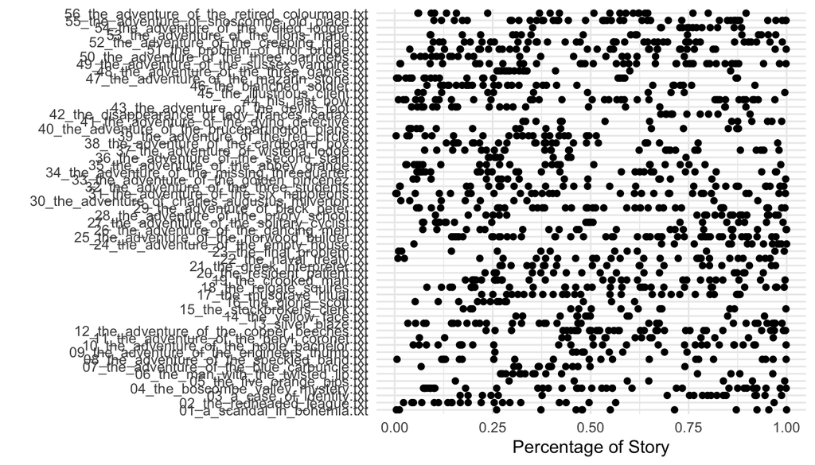

```r
ner_characters %>%
  semi_join(top_characters) %>%
  left_join(summarize(group_by(token, doc_id), total_sid = max(sid))) %>%
  mutate(percent = sid / total_sid) %>%
  ggplot(aes(percent, basename(text_names[doc_id]))) +
    geom_point() +
    xlab("Percentage of Story") + ylab("")
```

Notice, for instance, that Irene Adler has relatively few mentions in the the first story compared to other characters in later installments.

# Other Languages

```r
camus_fr <- "Aujourd'hui, maman est morte. Ou peut-être hier, je ne sais pas. J'ai reçu un télégramme de l'asile."
```

Here is what happens when we use the English model:

```r
cnlp_init_udpipe()
anno <- cnlp_annotate(camus_fr)$token
```

```
## Processed document 1 of 1
```

```r
anno$token
```

```
##  [1] "Aujourd"    "'hui"       ","          "maman"      "est"
##  [6] "morte"      "."          "Ou"         "peut"       "-"
## [11] "être"       "hier"       ","          "je"         "ne"
## [16] "sais"       "pas"        "."          "J'ai"       "reçu"
## [21] "un"         "télégramme" "de"         "l'asile"    "."
```

Not terrible, but it incorrectly splits the single tokens “Aujourd’hui” and “peut-être” into two parts but does not split the two tokens “J’ai”. The other parts of the NLP pipeline are even more effected. Look, for example at the lemmas and part of speech codes, which are almost all incorrect:

```r
anno
```

```
## # A tibble: 25 x 11
##    doc_id   sid tid   token token_with_ws lemma upos  xpos  feats
##  *  <int> <int> <chr> <chr> <chr>         <chr> <chr> <chr> <chr>
##  1      1     1 1     Aujo… "Aujourd"     Aujo… PROPN NNP   Numb…
##  2      1     1 2     'hui  "'hui"        'hui  PROPN NNP   Numb…
##  3      1     1 3     ,     ", "          ,     PUNCT ,     <NA>
##  4      1     1 4     maman "maman "      maman DET   DT    Defi…
##  5      1     1 5     est   "est "        est   ADJ   JJ    Degr…
##  6      1     1 6     morte "morte"       morte NOUN  NN    Numb…
##  7      1     1 7     .     ". "          .     PUNCT .     <NA>
##  8      1     2 1     Ou    "Ou "         Oough PRON  PRP   Case…
##  9      1     2 2     peut  "peut"        peut  VERB  VBD   Mood…
## 10      1     2 3     -     "-"           -     PUNCT ,     <NA>
## # … with 15 more rows, and 2 more variables: tid_source <chr>,
## #   relation <chr>
```

If we instead load the French model, these issues are fixed:

```r
cnlp_init_udpipe("french")
anno <- cnlp_annotate(camus_fr)$token
```

```
## Processed document 1 of 1
```

```r
anno
```

```
## # A tibble: 24 x 11
##    doc_id   sid tid   token token_with_ws lemma upos  xpos  feats
##  *  <int> <int> <chr> <chr> <chr>         <chr> <chr> <chr> <chr>
##  1      1     1 1     Aujo… "Aujourd'hui" aujo… ADV   <NA>  <NA>
##  2      1     1 2     ,     ", "          ,     PUNCT <NA>  <NA>
##  3      1     1 3     maman "maman "      maman PROPN <NA>  <NA>
##  4      1     1 4     est   "est "        être  AUX   <NA>  Mood…
##  5      1     1 5     morte "morte"       mour… VERB  <NA>  Gend…
##  6      1     1 6     .     ". "          .     PUNCT <NA>  <NA>
##  7      1     2 1     Ou    "Ou "         ou    CCONJ <NA>  <NA>
##  8      1     2 2     peut… "peut-être "  peut… ADV   <NA>  <NA>
##  9      1     2 3     hier  "hier"        hier  ADV   <NA>  <NA>
## 10      1     2 4     ,     ", "          ,     PUNCT <NA>  <NA>
## # … with 14 more rows, and 2 more variables: tid_source <chr>,
## #   relation <chr>
```